# Factor Models

Ryan Farhab

2022-09-30

This is the R markdown (rmd) exercise file that accompanies the lecture notes. It will be your sandbox! Fill in the R code chunks, experiment, and have fun!

# Factor Models

### Factor Models

Reading: Ch5 of Ang’s text.

# CAPM

### Getting Data

Pick a stock other than IBM, and download the price data:

```r
library(quantmod)
stock_symbol <- "TSLA"
stock_data <- getSymbols(stock_symbol, auto.assign=FALSE)
```

### Monthly Return

Calculate the monthly returns on the stock, and convert the returns to percentage terms:

```r
Close <- Ad(stock_data)
monthly.price <- to.monthly(Close)
monthly.Close <- monthly.price[,4]
r_monthly <- Delt(monthly.Close) * 100
names(r_monthly) <- 'r_i'
r_monthly <- na.omit(r_monthly)
head(r_monthly)
```

```
##                 r_i
## Jul 2010 -16.324000
## Aug 2010  -2.306871
## Sep 2010   4.774126
## Oct 2010   7.006343
## Nov 2010  61.767376
## Dec 2010 -24.624968
```

### Make it a function

```r
getMonthlyReturn <- function(stock_data, name = "r_monthly"){
  Close <- Ad(stock_data)

  monthly.price <- to.monthly(Close)

  monthly.Close <- monthly.price[,4]
  r_monthly <- Delt(monthly.Close) * 100
  names(r_monthly) <- name
  r_monthly <- na.omit(r_monthly)
  return(r_monthly)
}
```

### Return on Individual Asset

Plot the time series of stock returns:

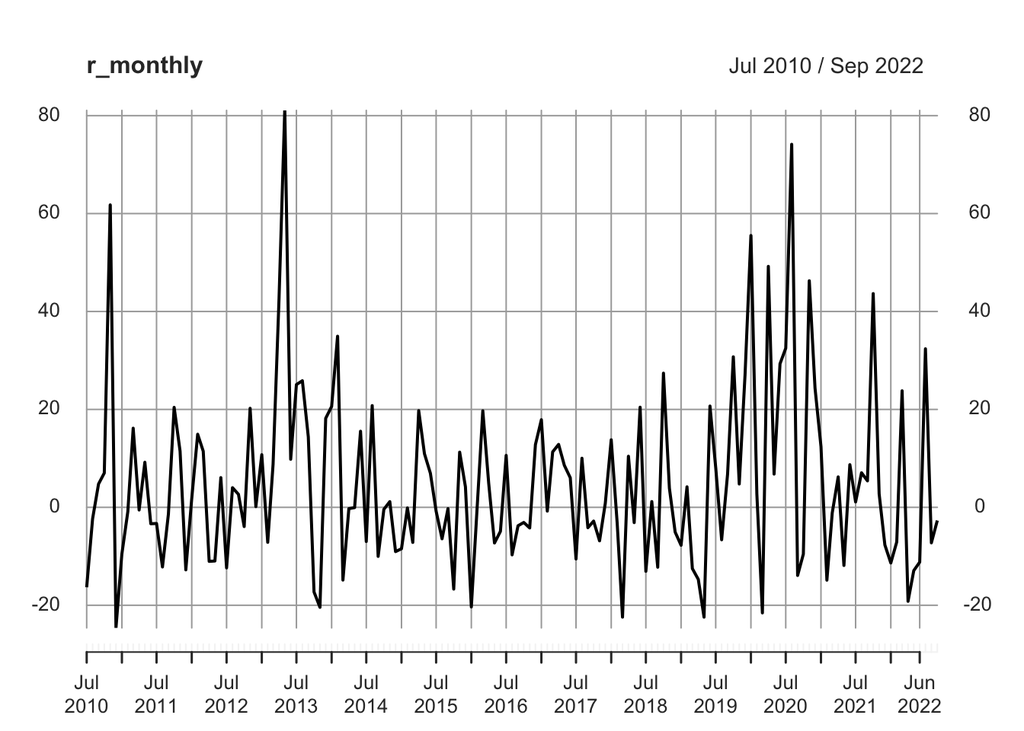

```r
plot(r_monthly)
```

### Market Index

Download S&P index data from Yahoo Finance:

```r
GSPC <- getSymbols("^GSPC", auto.assign = FALSE)
```

### Market Return

Calculate the monthly returns on the S&P 500 index:

```r
r_m <- getMonthlyReturn(GSPC, "r_m")
head(r_m)
```

```
##                 r_m
## Feb 2007 -2.1846176
## Mar 2007  0.9979983
## Apr 2007  4.3290691
## May 2007  3.2549229
## Jun 2007 -1.7816322
## Jul 2007 -3.1981878
```

### Market Return

Plot the time series of market returns:

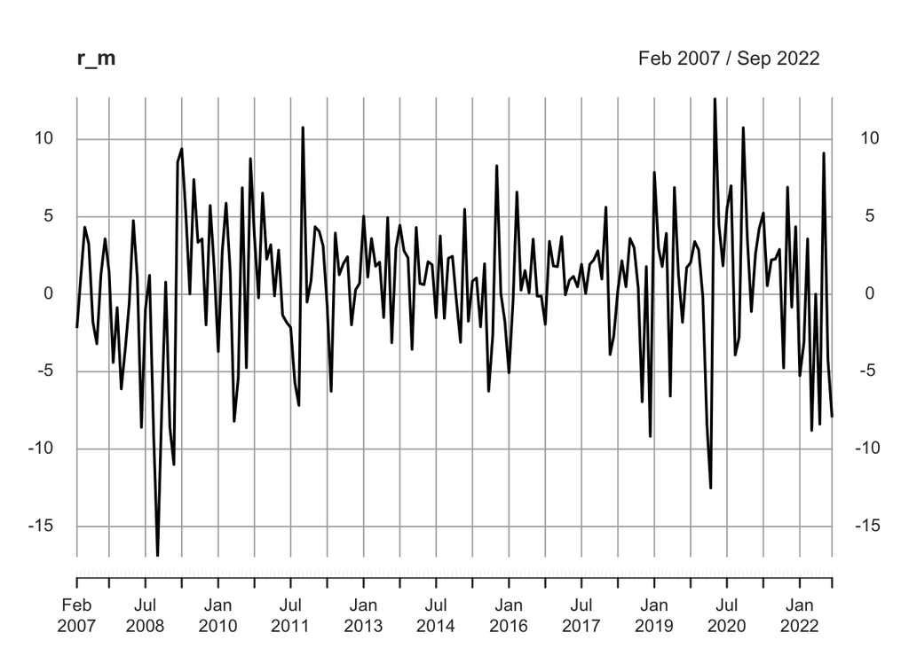

```r
plot(r_m)
```

### Risk-Free Rate Data

Download the one-month Treasury Constant Maturity Rate from: https://fred.stlouisfed.org/series/GS1M

Read in the risk-free rates:

```r
GS1M <- read.csv("GS1M.csv", header = TRUE)

GS1M$DATE <- as.Date(GS1M$DATE, format="%Y-%m-%d")
GS1M$DATE <- as.yearmon(GS1M$DATE)
r_f_annualized <- xts(GS1M[,2], order.by = GS1M$DATE)
names(r_f_annualized) <- "r_f"
```

### Convert the annuaized yield to back monthly yield

Convert the risk-free rate to a monthly yield:

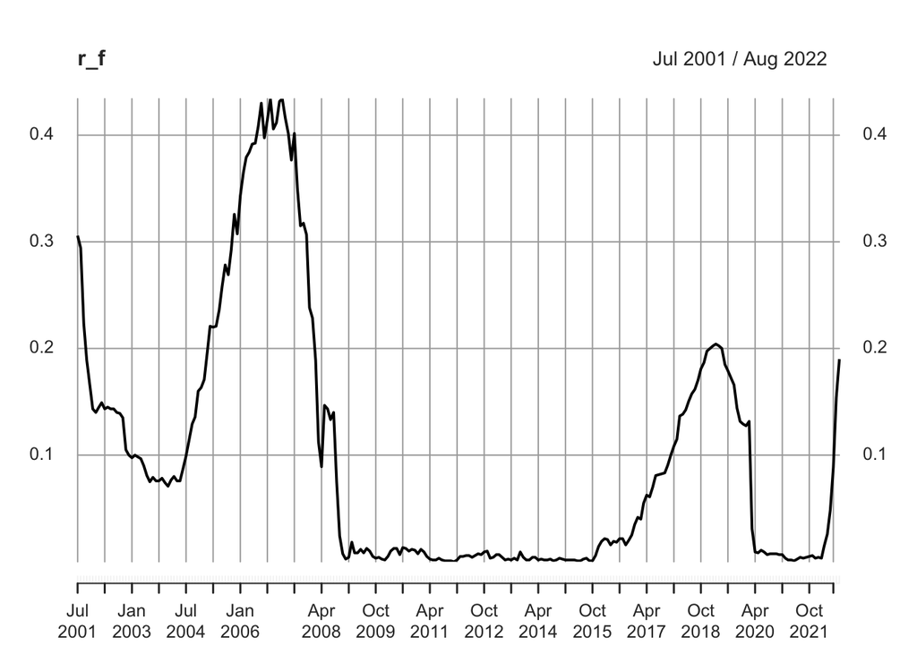

```r
r_f <- r_f_annualized / 12
plot(r_f)
```

How did the short-term rate change with economic cycle?

### Combining the rates

Combine the individual asset returns, market returns, and risk-free rates, and subset the data to drop the NA’s of the initial observations:

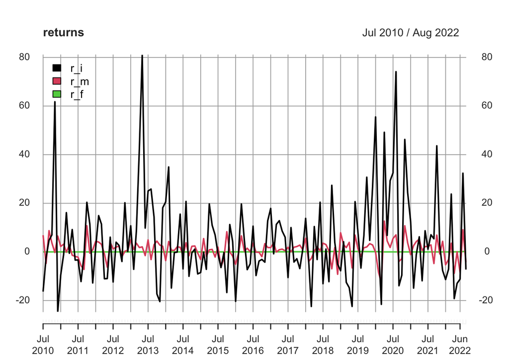

```r
returns <- cbind(r_monthly, r_m, r_f)
returns <- na.omit(returns)
plot(returns, legend.loc = "topleft")
```

### Calculate Excess Returns

```r
returns$R_i <- returns$r_i - returns$r_f
R_i <- returns$R_i

returns$R_m <- returns$r_m - returns$r_f
R_m <- returns$R_m

head(returns)
```

```
##                 r_i       r_m        r_f        R_i        R_m
## Jul 2010 -16.324000  6.877785 0.01333333 -16.337333  6.8644517
## Aug 2010  -2.306871 -4.744918 0.01250000  -2.319371 -4.7574184
## Sep 2010   4.774126  8.755110 0.01000000   4.764126  8.7451103
## Oct 2010   7.006343  3.685599 0.01166667   6.994677  3.6739328
## Nov 2010  61.767376 -0.229025 0.01083333  61.756543 -0.2398583
## Dec 2010 -24.624968  6.530004 0.00750000 -24.632468  6.5225040
```

### Scatter Plot: $R_i$ vs. $R_m$

Make a scatter plot of stock return against market return:

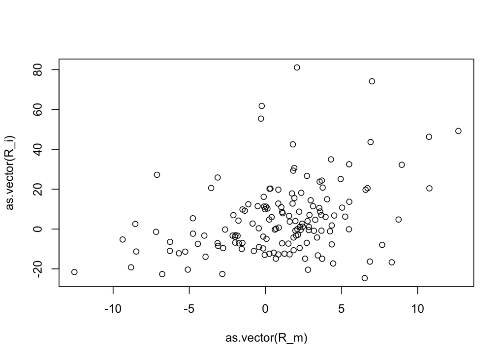

```r
plot(as.vector(R_m), as.vector(R_i))
```

### Estiamte CAPM

Run the linear regression to estimate the CAPM:

```r
CAPM <- lm(R_i ~ R_m)
summary(CAPM)
```

```
##
## Call:
## lm(formula = R_i ~ R_m)
##
## Residuals:
##     Min      1Q  Median      3Q     Max
## -38.458  -9.859  -3.348   7.552  74.336
##
## Coefficients:
##             Estimate Std. Error t value Pr(>|t|)
## (Intercept)   3.4243     1.4551   2.353     0.02 *
## R_m           1.5946     0.3453   4.619 8.49e-06 ***
## ---
## Signif. codes:  0 '***' 0.001 '**' 0.01 '*' 0.05 '.' 0.1 ' ' 1
##
## Residual standard error: 17.11 on 144 degrees of freedom
## Multiple R-squared:  0.129,  Adjusted R-squared:  0.123
## F-statistic: 21.33 on 1 and 144 DF,  p-value: 8.494e-06
```

### Regression Line

Add the regression line to the scatter plot using abline():

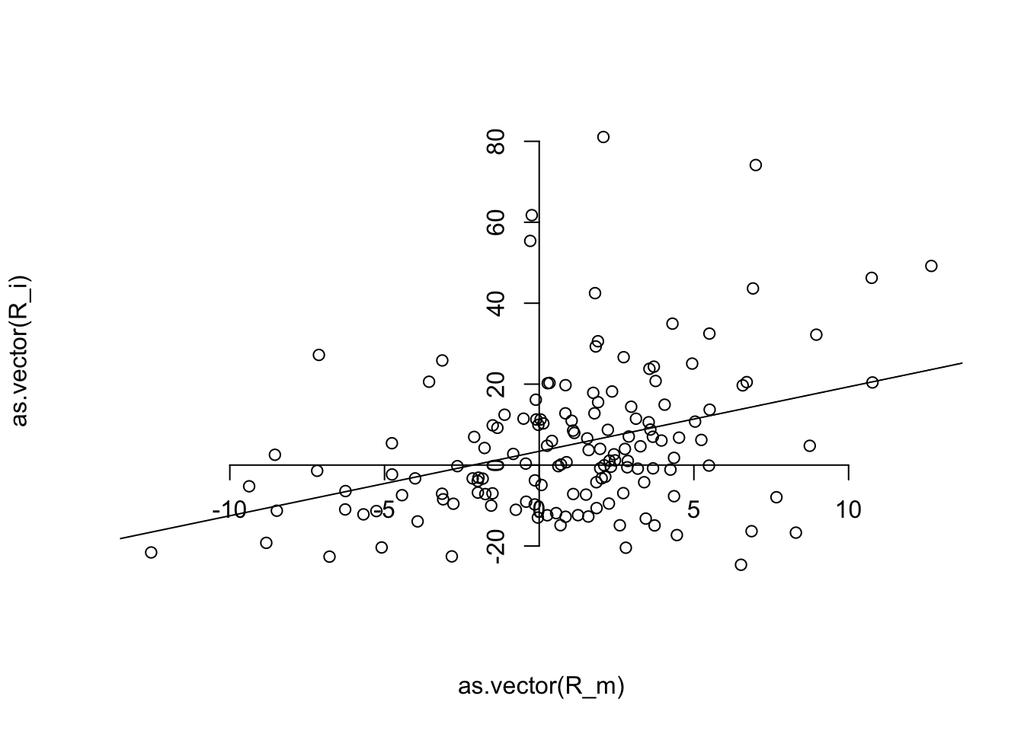

```r
plot(as.vector(R_m), as.vector(R_i), axes = FALSE)
abline(CAPM)

axis(1, pos = 0)
axis(2, pos = 0)
```

Reading: https://www.theanalysisfactor.com/linear-models-r-plotting-regression-lines/

Also check out the help on abline() that adds straight lines to existing plot.

### Intepretation

Inteprete your regression results. Is the alpha estimate statistically significant? Is the beta estimate statistically significant?

```r
summary(CAPM)$coefficients
```

```
##             Estimate Std. Error  t value     Pr(>|t|)
## (Intercept) 3.424349  1.4550537 2.353418 1.995373e-02
## R_m         1.594622  0.3452655 4.618538 8.493764e-06
```

```r
(alpha <- CAPM$coefficients[1])
```

```
## (Intercept)
##    3.424349
```

```r
(beta <- CAPM$coefficients[2])
```

```
##      R_m
## 1.594622
```

### Idiosyncratic Risk and Systematic Risk

Based on the scatter plot and the CAPM regression line, expain idiosyncratic risk vs. systematic risk.

### Idiosyncratic Risk

Plot the residuals of the CAPM regression:

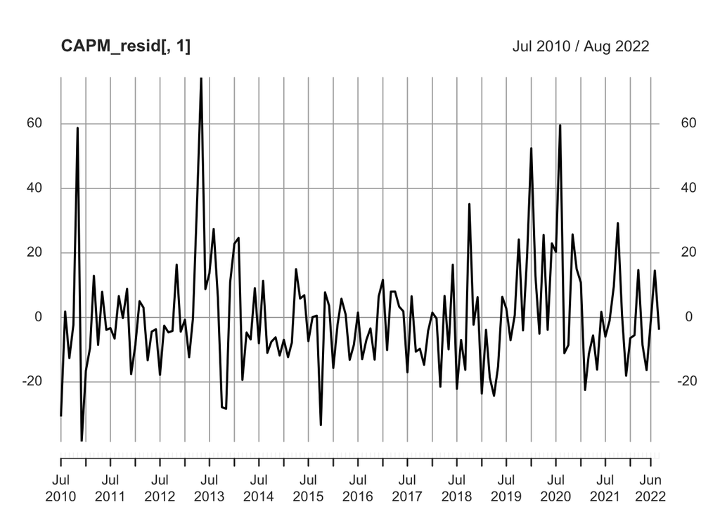

```r
CAPM_resid <- residuals(CAPM)
plot(CAPM_resid[,1])
```

```r
(idiosyncratic_risk <- var(CAPM_resid))
```

```
## [1] 290.8375
```

### Risk Decomposition: The Calculation

Decompose total risk into idiosyncratic risk and systematic risk:

```r
(total_risk <- var(R_i))
```

```
##          R_i
## R_i 333.9196
```

```r
(systematic_risk <- total_risk - idiosyncratic_risk)
```

```
##          R_i
## R_i 43.08211
```

Can you create a bar chart to plot the three types of risk?

### Risk Decomposition: The Theory

Calculate systematic risk directly:

```r
beta^2 * var(R_m)
```

```
##          R_m
## R_m 43.08211
```

### Regression Function

Define a function that returns the regression beta, where the input is an xts object with stock excess return R_i and market excess return R_m:

```r
get_beta <- function(X)
{
  roll.reg=lm(R_i ~ R_m, data = X)
  return(roll.reg$coef[2])
}
get_beta(returns)
```

```
##      R_m
## 1.594622
```

### Rolling Window Regression

Use rollapply() to estimate the rolling beta:

```r
betas_over_time <- rollapply(returns,
                             width = 60,
                             FUN = get_beta, by.column = FALSE)
```

### Time-Varying Beta

Plot the betas. How does it change over time?

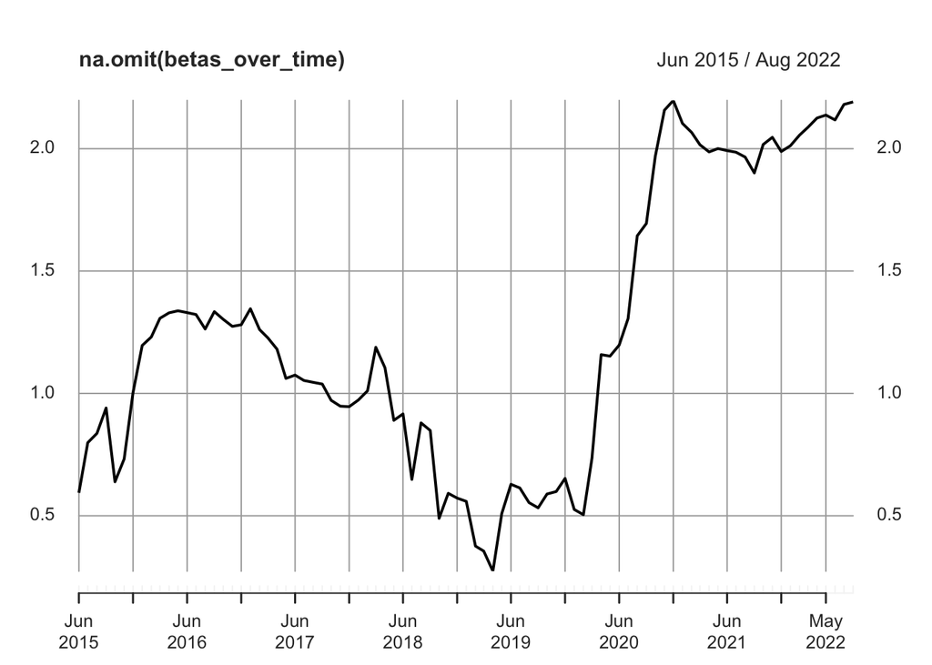

```r
plot(na.omit(betas_over_time))
```

# Fama-French Three-Factor Model

### Portfolios Formed on Size and Book-to-Market

### 25 Portfolios Formed on Size and Book-to-Market

Download and import the 25 size and book-to-market portfolios from Ken French’s data library. The link is: http://mba.tuck.dartmouth.edu/pages/faculty/ken.french/ftp/25_Portfolios_5x5_CSV.zip

Use read.csv() to import the data. The data file contains both monthly and annual data. Specify “nrows” in the read.csv() to specify the maximum number of rows to read in only the monthly data.

```r
size_BM_portfolios <- read.csv(
  file = "25_Portfolios_5x5.CSV",
  skip = 15,
  nrows = 1119-16)
```

### Average Returns

Use apply() to apply mean() to each column to calculate the average return for each portfolio.

```r
(average_returns <- apply(size_BM_portfolios[,2:26], MARGIN = 2, FUN = mean))
```

```
## SMALL.LoBM    ME1.BM2    ME1.BM3    ME1.BM4 SMALL.HiBM    ME2.BM1    ME2.BM2
##  0.8643323  0.9698844  1.3145902  1.4678182  1.6288142  0.9148016  1.2180285
##    ME2.BM3    ME2.BM4    ME2.BM5    ME3.BM1    ME3.BM2    ME3.BM3    ME3.BM4
##  1.2566845  1.3366550  1.5441007  0.9979769  1.1792986  1.2098982  1.3008255
##    ME3.BM5    ME4.BM1    ME4.BM2    ME4.BM3    ME4.BM4    ME4.BM5   BIG.LoBM
##  1.4014736  1.0032482  1.0559809  1.1296859  1.2400630  1.3426383  0.9117565
##    ME5.BM2    ME5.BM3    ME5.BM4   BIG.HiBM
##  0.8959300  0.9926495  0.9344032  1.2108434
```

### Average Returns: Reshaped

Reshaped the average return vector into a 5x5 matrix:

```r
average_returns_mat <- matrix(average_returns, nrow = 5)
colnames(average_returns_mat) <- c("SMALL", "ME2", "ME3", "ME4", "BIG")
rownames(average_returns_mat) <- c("LoBM", "BM2", "BM3", "BM4", "HiBM")
average_returns_mat
```

```
##          SMALL       ME2       ME3      ME4       BIG
## LoBM 0.8643323 0.9148016 0.9979769 1.003248 0.9117565
## BM2  0.9698844 1.2180285 1.1792986 1.055981 0.8959300
## BM3  1.3145902 1.2566845 1.2098982 1.129686 0.9926495
## BM4  1.4678182 1.3366550 1.3008255 1.240063 0.9344032
## HiBM 1.6288142 1.5441007 1.4014736 1.342638 1.2108434
```

Across the size dimension, what did you find? Across the book-to-market dimension, what did you find?

### Heat Map

You may have to install the gplots package first. On the console, issue the following command:

install.packages(“gplots”)

Then create a heatmap to visualize the table of average returns:

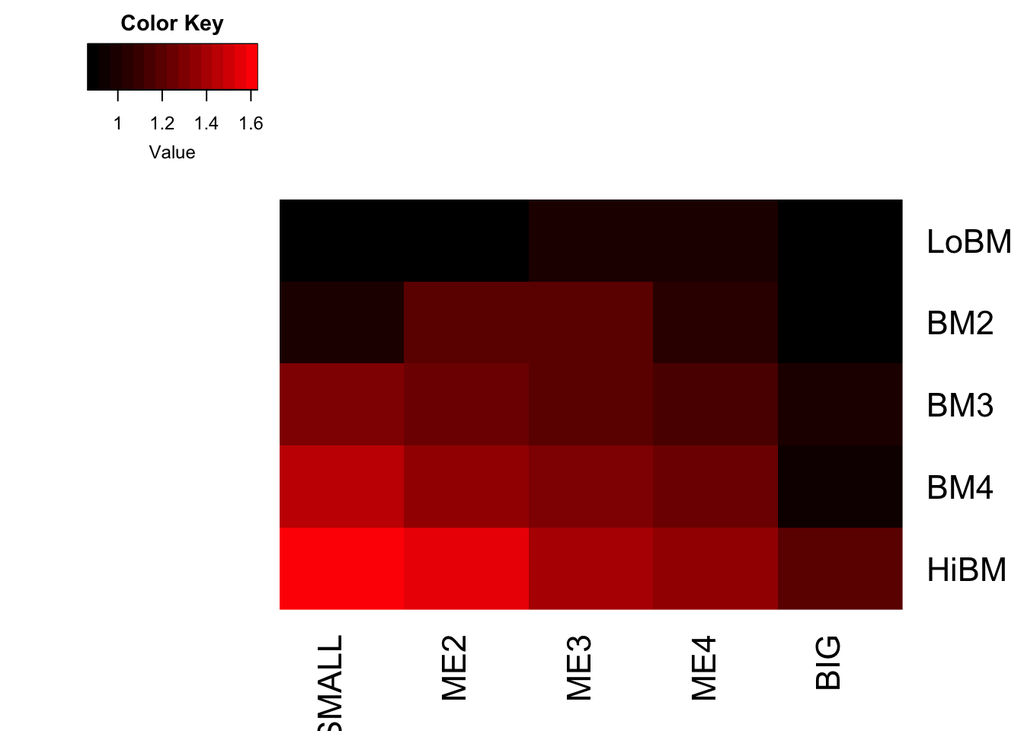

```r
library(gplots)
colfunc <- colorRampPalette(c("black", "red"))
heatmap.2(average_returns_mat, Rowv=NA, Colv=NA,
          col=colfunc(15), tracecol=NA, density.info='none')
```

This is a good article on generating heat map in R:

https://davetang.org/muse/2010/12/06/making-a-heatmap-with-r/

### Empirical Difficulty of CAPM

The paper every finance student should read: Fama and French (1992) The Cross‐Section of Expected Stock Returns, available at: https://onlinelibrary.wiley.com/doi/abs/10.1111/j.1540-6261.1992.tb04398.x

### Fama-French Three-Factor Model

Another paper by Fama and French: Common risk factors in the returns on stocks and bonds, https://www.sciencedirect.com/science/article/pii/0304405X93900235

### Data

The data file is http://mba.tuck.dartmouth.edu/pages/faculty/ken.french/ftp/F-F_Research_Data_Factors_CSV.zip

Download the CSV version and unzip it. And read in the text file with read.csv(). The data file contains both monthly and annual data. Specify “nrows” in the read.csv() to specify the maximum number of rows to read in only the monthly data.

```r
FF.raw <- read.csv(file = "F-F_Research_Data_Factors.csv", skip = 3, nrows = 1103)
```

### A quick view

Check the head and tail of the data.

```r
head(FF.raw)
```

```
##        X Mkt.RF   SMB   HML   RF
## 1 192607   2.96 -2.56 -2.43 0.22
## 2 192608   2.64 -1.17  3.82 0.25
## 3 192609   0.36 -1.40  0.13 0.23
## 4 192610  -3.24 -0.09  0.70 0.32
## 5 192611   2.53 -0.10 -0.51 0.31
## 6 192612   2.62 -0.03 -0.05 0.28
```

```r
tail(FF.raw)
```

```
##           X Mkt.RF   SMB   HML   RF
## 1098 201712   1.06 -1.32  0.05 0.09
## 1099 201801   5.57 -3.15 -1.33 0.12
## 1100 201802  -3.65  0.23 -1.07 0.11
## 1101 201803  -2.35  4.05 -0.23 0.11
## 1102 201804   0.28  1.14  0.54 0.14
## 1103 201805   2.65  5.26 -3.18 0.14
```

### Convert the data frame to xts

Convert the FF factors to xts:

```r
FF_yearmonth <- as.yearmon(as.character(FF.raw[,1]),
                           format = "%Y%m")
FF_factors <- xts(FF.raw[,2:5], order.by = FF_yearmonth)
```

### Mutual Fund

Reading: https://www.fidelity.com/learning-center/investment-products/mutual-funds/what-are-mutual-funds

Select a mutual fund (other than LSVEX) to apply the FF Model. You can find some of the “best” mutual funds here:

https://money.usnews.com/funds/mutual-funds/most-popular

### Mutual Fund Data

Download the mutual fund historical prices from Yahoo Finance:

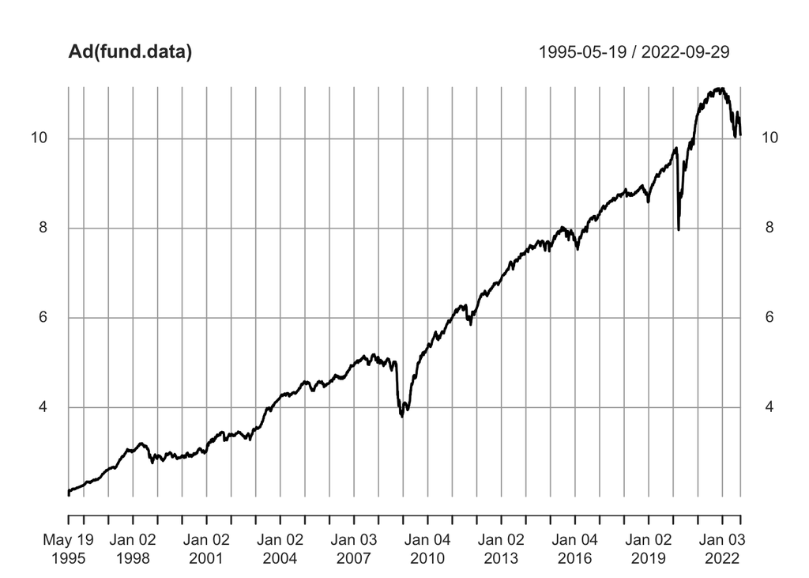

```r
fund.data <- getSymbols("BUFHX",
                        auto.assign = FALSE,
                        from = "1900-01-01")
plot(Ad(fund.data))
```

### Mutual fund returns

Calculate and plot the mutual fund’s monthly returns:

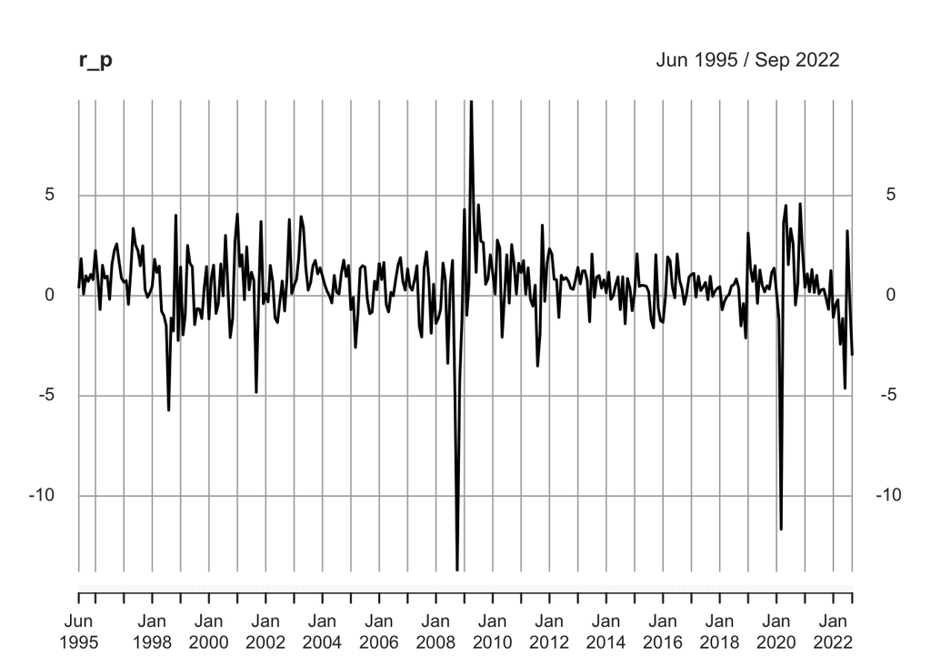

```r
r_p <- getMonthlyReturn(fund.data, "r_p")
plot(r_p)
```

### Merging the data

Merge the mutual fund returns with the FF factors:

```r
FF_returns <- na.omit(cbind(FF_factors, r_p))
head(FF_returns)
```

```
##          Mkt.RF   SMB   HML   RF        r_p
## Jun 1995   2.72  3.18 -2.54 0.47 0.37179106
## Jul 1995   3.72  2.07 -1.62 0.45 1.85183631
## Aug 1995   0.55  1.35  2.79 0.47 0.09101135
## Sep 1995   3.35 -2.20 -0.04 0.43 0.99907105
## Oct 1995  -1.52 -3.78 -0.50 0.47 0.71937266
## Nov 1995   3.96 -1.09  0.51 0.42 1.07137446
```

```r
tail(FF_returns)
```

```
##          Mkt.RF   SMB   HML   RF         r_p
## Dec 2017   1.06 -1.32  0.05 0.09  0.37448762
## Jan 2018   5.57 -3.15 -1.33 0.12  0.45529989
## Feb 2018  -3.65  0.23 -1.07 0.11 -0.70412043
## Mar 2018  -2.35  4.05 -0.23 0.11 -0.28851704
## Apr 2018   0.28  1.14  0.54 0.14 -0.04697226
## May 2018   2.65  5.26 -3.18 0.14  0.07304641
```

### Excess Returns

Calculate the excess return on the mutual fund

```r
FF_returns$R_p <- FF_returns$r_p - FF_returns$RF
head(FF_returns)
```

```
##          Mkt.RF   SMB   HML   RF        r_p         R_p
## Jun 1995   2.72  3.18 -2.54 0.47 0.37179106 -0.09820894
## Jul 1995   3.72  2.07 -1.62 0.45 1.85183631  1.40183631
## Aug 1995   0.55  1.35  2.79 0.47 0.09101135 -0.37898865
## Sep 1995   3.35 -2.20 -0.04 0.43 0.99907105  0.56907105
## Oct 1995  -1.52 -3.78 -0.50 0.47 0.71937266  0.24937266
## Nov 1995   3.96 -1.09  0.51 0.42 1.07137446  0.65137446
```

### Fama-French 3-Factor Model Regression

Estimate the FF 3-factor model for the mutual fund:

```r
FF_model <- lm(R_p ~ Mkt.RF + HML + SMB, data = FF_returns)
summary(FF_model)
```

```
##
## Call:
## lm(formula = R_p ~ Mkt.RF + HML + SMB, data = FF_returns)
##
## Residuals:
##     Min      1Q  Median      3Q     Max
## -8.8094 -0.5504 -0.0003  0.6015  7.6272
##
## Coefficients:
##             Estimate Std. Error t value Pr(>|t|)
## (Intercept)  0.12086    0.07919   1.526    0.128
## Mkt.RF       0.26673    0.01850  14.415  < 2e-16 ***
## HML          0.11354    0.02630   4.317 2.21e-05 ***
## SMB          0.11089    0.02458   4.511 9.60e-06 ***
## ---
## Signif. codes:  0 '***' 0.001 '**' 0.01 '*' 0.05 '.' 0.1 ' ' 1
##
## Residual standard error: 1.295 on 272 degrees of freedom
## Multiple R-squared:  0.4932, Adjusted R-squared:  0.4876
## F-statistic: 88.23 on 3 and 272 DF,  p-value: < 2.2e-16
```

What is your intepretations of the results?

### Compared to CAPM

Estimate the CAPM for the mutual fund:

```r
CAPM <- lm(R_p ~ Mkt.RF, data = FF_returns)
summary(CAPM)
```

```
##
## Call:
## lm(formula = R_p ~ Mkt.RF, data = FF_returns)
##
## Residuals:
##     Min      1Q  Median      3Q     Max
## -9.2621 -0.5063 -0.0203  0.6265  6.7980
##
## Coefficients:
##             Estimate Std. Error t value Pr(>|t|)
## (Intercept)  0.15527    0.08294   1.872   0.0623 .
## Mkt.RF       0.27435    0.01887  14.537   <2e-16 ***
## ---
## Signif. codes:  0 '***' 0.001 '**' 0.01 '*' 0.05 '.' 0.1 ' ' 1
##
## Residual standard error: 1.362 on 274 degrees of freedom
## Multiple R-squared:  0.4354, Adjusted R-squared:  0.4334
## F-statistic: 211.3 on 1 and 274 DF,  p-value: < 2.2e-16
```